# **Marketplace Analytics: FoodHub Courier Demand and Sales Optimization**

### Context

The number of restaurants in New York is increasing day by day. Lots of students and busy professionals rely on those restaurants due to their hectic lifestyles. Online food delivery service is a great option for them. It provides them with good food from their favorite restaurants. A food aggregator company FoodHub offers access to multiple restaurants through a single smartphone app.

The app allows the restaurants to receive a direct online order from a customer. The app assigns a delivery person from the company to pick up the order after it is confirmed by the restaurant. The delivery person then uses the map to reach the restaurant and waits for the food package. Once the food package is handed over to the delivery person, he/she confirms the pick-up in the app and travels to the customer's location to deliver the food. The delivery person confirms the drop-off in the app after delivering the food package to the customer. The customer can rate the order in the app. The food aggregator earns money by collecting a fixed margin of the delivery order from the restaurants.

### Objective

The food aggregator company has stored the data of the different orders made by the registered customers in their online portal. They want to analyze the data to get a fair idea about the demand of different restaurants which will help them in enhancing their customer experience. Suppose you are hired as a Data Scientist in this company and the Data Science team has shared some of the key questions that need to be answered. Perform the data analysis to find answers to these questions that will help the company to improve the business.

### Data Description

The data contains the different data related to a food order. The detailed data dictionary is given below.

### Data Dictionary

- order_id: Unique ID of the order
- customer_id: ID of the customer who ordered the food
- restaurant_name: Name of the restaurant
- cuisine_type: Cuisine ordered by the customer
- cost: Cost of the order
- day_of_the_week: Indicates whether the order is placed on a weekday or weekend (The weekday is from Monday to Friday and the weekend is Saturday and Sunday)
- rating: Rating given by the customer out of 5
- food_preparation_time: Time (in minutes) taken by the restaurant to prepare the food. This is calculated by taking the difference between the timestamps of the restaurant's order confirmation and the delivery person's pick-up confirmation.
- delivery_time: Time (in minutes) taken by the delivery person to deliver the food package. This is calculated by taking the difference between the timestamps of the delivery person's pick-up confirmation and drop-off information

```python
# importing libraries for data manipulation
import numpy as np
import pandas as pd
import sqlite3

# importing libraries for data visualization
import matplotlib.pyplot as plt
import seaborn as sns
```

```python
# read the data
from google.colab import drive
drive.mount('/content/drive')
```

```python
df = pd.read_csv('/content/drive/MyDrive/DSAAI Notebooks and Learning Material/foodhub_order.csv')
# returns the first 5 rows
df.head()
```

|  | order_id | customer_id | restaurant_name | cuisine_type | cost_of_the_order | day_of_the_week | rating | food_preparation_time | delivery_time |
| --- | --- | --- | --- | --- | --- | --- | --- | --- | --- |
| 0 | 1477147 | 337525 | Hangawi | Korean | 30.75 | Weekend | Not given | 25 | 20 |
| 1 | 1477685 | 358141 | Blue Ribbon Sushi Izakaya | Japanese | 12.08 | Weekend | Not given | 25 | 23 |
| 2 | 1477070 | 66393 | Cafe Habana | Mexican | 12.23 | Weekday | 5 | 23 | 28 |
| 3 | 1477334 | 106968 | Blue Ribbon Fried Chicken | American | 29.20 | Weekend | 3 | 25 | 15 |
| 4 | 1478249 | 76942 | Dirty Bird to Go | American | 11.59 | Weekday | 4 | 25 | 24 |

```python
# Creating a SQLite database file
conn = sqlite3.connect('foodhub_order.db')
```

```python
# Write the dataframe into SQLite as a table
df.to_sql("orders", conn, if_exists="replace", index=False)

print("Rows loaded into SQLite:", len(df))
```

```
Rows loaded into SQLite: 1898
```

After loading the raw dataset into SQLite, the next EDA step inspects structural properties of the table through SQL. Schema inspection, categorical frequency counts, and numerical summaries are performed at the database layer before deeper analysis continues in Python.

```python
# Checking data info
query = """
SELECT *
FROM orders
LIMIT 10;
"""

pd.read_sql(query, conn)
```

|  | order_id | customer_id | restaurant_name | cuisine_type | cost_of_the_order | day_of_the_week | rating | food_preparation_time | delivery_time |
| --- | --- | --- | --- | --- | --- | --- | --- | --- | --- |
| 0 | 1477147 | 337525 | Hangawi | Korean | 30.75 | Weekend | Not given | 25 | 20 |
| 1 | 1477685 | 358141 | Blue Ribbon Sushi Izakaya | Japanese | 12.08 | Weekend | Not given | 25 | 23 |
| 2 | 1477070 | 66393 | Cafe Habana | Mexican | 12.23 | Weekday | 5 | 23 | 28 |
| 3 | 1477334 | 106968 | Blue Ribbon Fried Chicken | American | 29.20 | Weekend | 3 | 25 | 15 |
| 4 | 1478249 | 76942 | Dirty Bird to Go | American | 11.59 | Weekday | 4 | 25 | 24 |
| 5 | 1477224 | 147468 | Tamarind TriBeCa | Indian | 25.22 | Weekday | 3 | 20 | 24 |
| 6 | 1477894 | 157711 | The Meatball Shop | Italian | 6.07 | Weekend | Not given | 28 | 21 |
| 7 | 1477859 | 89574 | Barbounia | Mediterranean | 5.97 | Weekday | 3 | 33 | 30 |
| 8 | 1477174 | 121706 | Anjappar Chettinad | Indian | 16.44 | Weekday | 5 | 21 | 26 |
| 9 | 1477311 | 39705 | Bukhara Grill | Indian | 7.18 | Weekday | 5 | 29 | 26 |

```python
# Describing data
schema_query = """
PRAGMA table_info(orders);
"""

pd.read_sql(schema_query, conn)
```

|  | cid | name | type | notnull | dflt_value | pk |
| --- | --- | --- | --- | --- | --- | --- |
| 0 | 0 | order_id | INTEGER | 0 | None | 0 |
| 1 | 1 | customer_id | INTEGER | 0 | None | 0 |
| 2 | 2 | restaurant_name | TEXT | 0 | None | 0 |
| 3 | 3 | cuisine_type | TEXT | 0 | None | 0 |
| 4 | 4 | cost_of_the_order | REAL | 0 | None | 0 |
| 5 | 5 | day_of_the_week | TEXT | 0 | None | 0 |
| 6 | 6 | rating | TEXT | 0 | None | 0 |
| 7 | 7 | food_preparation_time | INTEGER | 0 | None | 0 |
| 8 | 8 | delivery_time | INTEGER | 0 | None | 0 |

```python
# Checking row count, distinct customers, distinct restaurants
eda_overview_query = """
SELECT
    COUNT(*) AS total_orders,
    COUNT(DISTINCT customer_id) AS unique_customers,
    COUNT(DISTINCT restaurant_name) AS unique_restaurants,
    COUNT(DISTINCT cuisine_type) AS unique_cuisines
FROM orders;
"""

pd.read_sql(eda_overview_query, conn)
```

|  | total_orders | unique_customers | unique_restaurants | unique_cuisines |
| --- | --- | --- | --- | --- |
| 0 | 1898 | 1200 | 178 | 14 |

```python
# Checking how many unique customers placed orders
unique_customers_query = """
SELECT COUNT(DISTINCT customer_id) AS unique_customers
FROM orders;
"""

pd.read_sql(unique_customers_query, conn)
```

|  | unique_customers |
| --- | --- |
| 0 | 1200 |

```python
# Checking min, max and average values for cost, prep and delivery times
numeric_summary_query = """
SELECT
    COUNT(*) AS total_rows,

    MIN(cost_of_the_order) AS min_cost,
    ROUND(AVG(cost_of_the_order), 2) AS avg_cost,
    MAX(cost_of_the_order) AS max_cost,

    MIN(food_preparation_time) AS min_prep_time,
    ROUND(AVG(food_preparation_time), 2) AS avg_prep_time,
    MAX(food_preparation_time) AS max_prep_time,

    MIN(delivery_time) AS min_delivery_time,
    ROUND(AVG(delivery_time), 2) AS avg_delivery_time,
    MAX(delivery_time) AS max_delivery_time
FROM orders;
"""

pd.read_sql(numeric_summary_query, conn)
```

|  | total_rows | min_cost | avg_cost | max_cost | min_prep_time | avg_prep_time | max_prep_time | min_delivery_time | avg_delivery_time | max_delivery_time |
| --- | --- | --- | --- | --- | --- | --- | --- | --- | --- | --- |
| 0 | 1898 | 4.47 | 16.5 | 35.41 | 20 | 27.37 | 35 | 15 | 24.16 | 33 |

### Observations:

The dataset is void of any missing values. The 'ratings' column does contain strings 'Not given' which will be treated accordingly throughout EDA to support insights (some problems will take into account the measure of 'Not given' and some will exclude rows containing them).

Four of the columns are categorical data: 'restaurant_name', 'cuisine type', 'day_of_the_week' and 'rating'.

The remaining five are currently numerical data: 'order_id', 'customer_id', 'cost_of_the_order', 'food_preparation_time' and 'delivery_time'.

There are more orders recorded than there are unique customers, indicating that there is are repeat customers within the data.

Quick check on data yields these windows:

Cost ranges from 4.47 to 35.41 dollars with an average of 16.5 dollars

Prep time ranges from 20 to 35 minutes with an average of 27.37 minutes

Delivery time ranges from 15 to 33 minutes with an average of 24.16 minutes

```python
# Checking order count by cuisine type
cuisine_dist_query = """
SELECT
    cuisine_type,
    COUNT(*) AS order_count
FROM orders
GROUP BY cuisine_type
ORDER BY order_count DESC;
"""

pd.read_sql(cuisine_dist_query, conn)
```

|  | cuisine_type | order_count |
| --- | --- | --- |
| 0 | American | 584 |
| 1 | Japanese | 470 |
| 2 | Italian | 298 |
| 3 | Chinese | 215 |
| 4 | Mexican | 77 |
| 5 | Indian | 73 |
| 6 | Middle Eastern | 49 |
| 7 | Mediterranean | 46 |
| 8 | Thai | 19 |
| 9 | French | 18 |
| 10 | Southern | 17 |
| 11 | Korean | 13 |
| 12 | Spanish | 12 |
| 13 | Vietnamese | 7 |

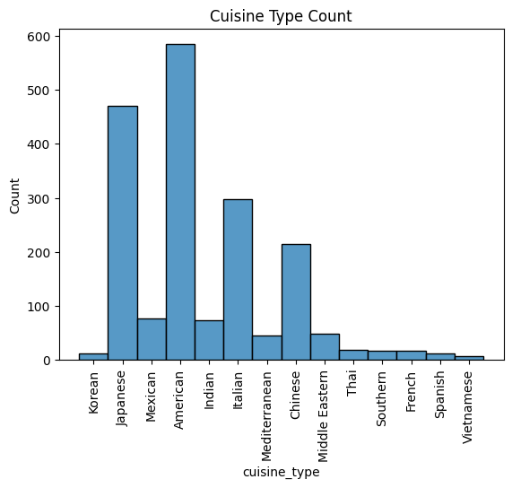

```python
# Visualizing order counts by cuisine type
sns.histplot(df['cuisine_type'])
plt.xticks(rotation=90)
plt.title("Cuisine Type Count")
plt.show()
```

```python
# Checking distribution of orders on weekday vs weekend
day_mix_query = """
SELECT
    day_of_the_week,
    COUNT(*) AS order_count,
    ROUND(100.0 * COUNT(*) / (SELECT COUNT(*) FROM orders), 2) AS pct_of_total_orders
FROM orders
GROUP BY day_of_the_week
ORDER BY order_count DESC;
"""

pd.read_sql(day_mix_query, conn)
```

|  | day_of_the_week | order_count | pct_of_total_orders |
| --- | --- | --- | --- |
| 0 | Weekend | 1351 | 71.18 |
| 1 | Weekday | 547 | 28.82 |

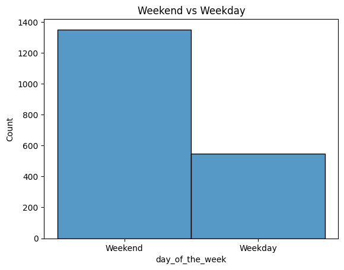

```python
# Showing counts on orders placed on weekdays vs orders placed on weekends
sns.histplot(df['day_of_the_week'])
plt.title("Weekend vs Weekday")
plt.show()
```

```python
# Checking which cuisines are most popular on weekends
weekend_cuisine_query = """
SELECT
    cuisine_type,
    COUNT(*) AS weekend_orders
FROM orders
WHERE day_of_the_week = 'Weekend'
GROUP BY cuisine_type
ORDER BY weekend_orders DESC;
"""

pd.read_sql(weekend_cuisine_query, conn)
```

|  | cuisine_type | weekend_orders |
| --- | --- | --- |
| 0 | American | 415 |
| 1 | Japanese | 335 |
| 2 | Italian | 207 |
| 3 | Chinese | 163 |
| 4 | Mexican | 53 |
| 5 | Indian | 49 |
| 6 | Middle Eastern | 32 |
| 7 | Mediterranean | 32 |
| 8 | Thai | 15 |
| 9 | French | 13 |
| 10 | Spanish | 11 |
| 11 | Southern | 11 |
| 12 | Korean | 11 |
| 13 | Vietnamese | 4 |

```python
# Checking which cuisines are most popular on weekdays
weekday_cuisine_query = """
SELECT
    cuisine_type,
    COUNT(*) AS weekday_orders
FROM orders
WHERE day_of_the_week = 'Weekday'
GROUP BY cuisine_type
ORDER BY weekday_orders DESC;
"""

pd.read_sql(weekday_cuisine_query, conn)
```

|  | cuisine_type | weekday_orders |
| --- | --- | --- |
| 0 | American | 169 |
| 1 | Japanese | 135 |
| 2 | Italian | 91 |
| 3 | Chinese | 52 |
| 4 | Mexican | 24 |
| 5 | Indian | 24 |
| 6 | Middle Eastern | 17 |
| 7 | Mediterranean | 14 |
| 8 | Southern | 6 |
| 9 | French | 5 |
| 10 | Thai | 4 |
| 11 | Vietnamese | 3 |
| 12 | Korean | 2 |
| 13 | Spanish | 1 |

```python
# Comparing cuisine demand across weekday vs weekend in one table
cuisine_day_compare_query = """
SELECT
    cuisine_type,
    SUM(CASE WHEN day_of_the_week = 'Weekday' THEN 1 ELSE 0 END) AS weekday_orders,
    SUM(CASE WHEN day_of_the_week = 'Weekend' THEN 1 ELSE 0 END) AS weekend_orders,
    COUNT(*) AS total_orders
FROM orders
GROUP BY cuisine_type
ORDER BY total_orders DESC;
"""

pd.read_sql(cuisine_day_compare_query, conn)
```

|  | cuisine_type | weekday_orders | weekend_orders | total_orders |
| --- | --- | --- | --- | --- |
| 0 | American | 169 | 415 | 584 |
| 1 | Japanese | 135 | 335 | 470 |
| 2 | Italian | 91 | 207 | 298 |
| 3 | Chinese | 52 | 163 | 215 |
| 4 | Mexican | 24 | 53 | 77 |
| 5 | Indian | 24 | 49 | 73 |
| 6 | Middle Eastern | 17 | 32 | 49 |
| 7 | Mediterranean | 14 | 32 | 46 |
| 8 | Thai | 4 | 15 | 19 |
| 9 | French | 5 | 13 | 18 |
| 10 | Southern | 6 | 11 | 17 |
| 11 | Korean | 2 | 11 | 13 |
| 12 | Spanish | 1 | 11 | 12 |
| 13 | Vietnamese | 3 | 4 | 7 |

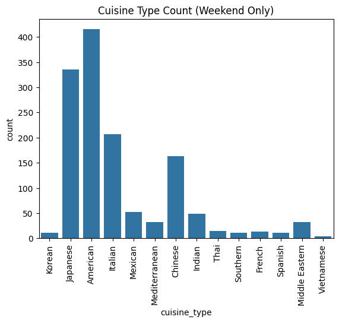

```python
# Visualizing order counts by cuisine on weekends
sns.countplot(data=df[df['day_of_the_week'] == 'Weekend'], x='cuisine_type')
plt.xticks(rotation=90)
plt.title("Cuisine Type Count (Weekend Only)")
plt.show()
```

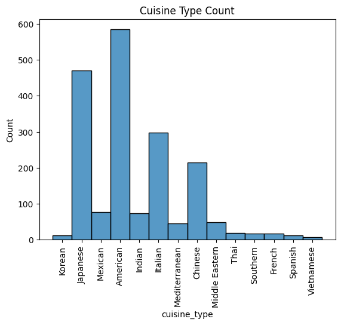

```python
# Checking order counts on each cuisine again
sns.histplot(df['cuisine_type'])
plt.xticks(rotation=90)
plt.title("Cuisine Type Count")
plt.show()
```

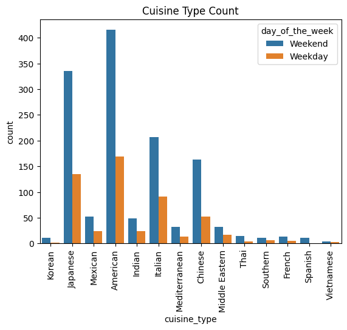

```python
# Visualizing notable differences between weekdays and weekends
sns.countplot(data=df, x = 'cuisine_type', hue = 'day_of_the_week')
plt.xticks(rotation=90)
plt.title("Cuisine Type Count")
plt.show()
```

### Observations:

Weekend orders make up a disproportionately large share of total volume despite covering fewer days, indicating a strong demand concentration during this period.

Cuisine preferences remain largely stable across the week, with American, Japanese, Italian, and Chinese consistently leading in order volume.

While lower-ranked cuisines exhibit minor shifts in ordering position between weekdays and weekends, these changes are marginal and do not materially affect overall demand patterns.

```python
# Checking which individual restaurants receive the most orders
top_restaurants_query = """
SELECT
    restaurant_name,
    COUNT(*) AS order_count
FROM orders
GROUP BY restaurant_name
ORDER BY order_count DESC
LIMIT 10;
"""

pd.read_sql(top_restaurants_query, conn)
```

|  | restaurant_name | order_count |
| --- | --- | --- |
| 0 | Shake Shack | 219 |
| 1 | The Meatball Shop | 132 |
| 2 | Blue Ribbon Sushi | 119 |
| 3 | Blue Ribbon Fried Chicken | 96 |
| 4 | Parm | 68 |
| 5 | RedFarm Broadway | 59 |
| 6 | RedFarm Hudson | 55 |
| 7 | TAO | 49 |
| 8 | Han Dynasty | 46 |
| 9 | Blue Ribbon Sushi Bar & Grill | 44 |

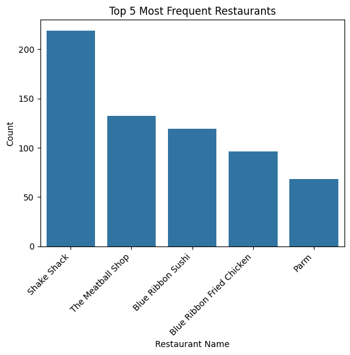

```python
# Creating a visual of order counts from top 5 restaurants in dataset
top5 = df['restaurant_name'].value_counts().head(5)
top5_df = top5.reset_index()
top5_df.columns = ['restaurant_name', 'count']
sns.barplot(data=top5_df, x='restaurant_name', y='count')

plt.xticks(rotation=45, ha='right')
plt.title("Top 5 Most Frequent Restaurants")
plt.xlabel("Restaurant Name")
plt.ylabel("Count")

plt.show()
```

Key Takeaways:

**Customers**

The number of unique customers is lower than the total number of orders, indicating repeat ordering behavior within the customer base.

**Day mix**

Order volume is substantially concentrated on weekends, suggesting stronger peak demand and untapped weekday potential.

**Cuisines**

**Popular restaurants**

The top five restaurants are Shake Shack, The Meatball Shop, Blue Ribbon Sushi, Blue Ribbon Fried Chicken and Parm, with rankings respective to that order. Each of these restaurants align with the most popular cuisines.

# Time Analysis

```python
timing_summary_query = """
SELECT
    ROUND(AVG(food_preparation_time), 2) AS avg_prep_time,
    MIN(food_preparation_time) AS min_prep_time,
    MAX(food_preparation_time) AS max_prep_time,

    ROUND(AVG(delivery_time), 2) AS avg_delivery_time,
    MIN(delivery_time) AS min_delivery_time,
    MAX(delivery_time) AS max_delivery_time,

    ROUND(AVG(food_preparation_time + delivery_time), 2) AS avg_total_fulfillment_time,
    MIN(food_preparation_time + delivery_time) AS min_total_fulfillment_time,
    MAX(food_preparation_time + delivery_time) AS max_total_fulfillment_time
FROM orders;
"""

pd.read_sql(timing_summary_query, conn)
```

|  | avg_prep_time | min_prep_time | max_prep_time | avg_delivery_time | min_delivery_time | max_delivery_time | avg_total_fulfillment_time | min_total_fulfillment_time | max_total_fulfillment_time |
| --- | --- | --- | --- | --- | --- | --- | --- | --- | --- |
| 0 | 27.37 | 20 | 35 | 24.16 | 15 | 33 | 51.53 | 35 | 68 |

### Observations:

Minimum amount of preparation time - 20 minutes

Average amount of preparation time - ~27.372 minutes

Maximum amount of preparation time - 35 minutes.

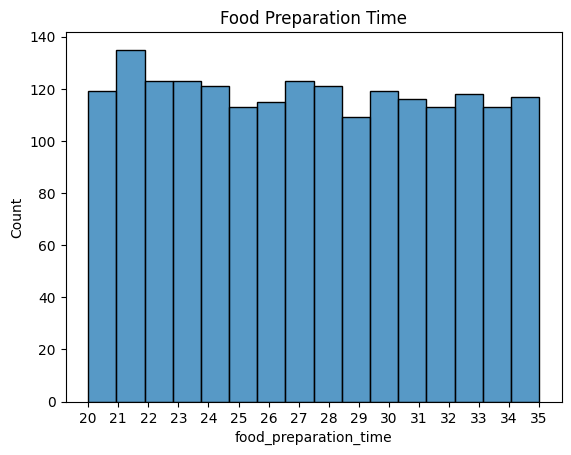

```python
# Visualizing the distribution of food preparation times
sns.histplot(df['food_preparation_time'], bins=16)
plt.title("Food Preparation Time")
plt.xticks(range(20, 36, 1))
plt.show()
```

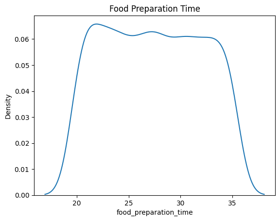

```python
sns.kdeplot(df['food_preparation_time'])
plt.title("Food Preparation Time")
```

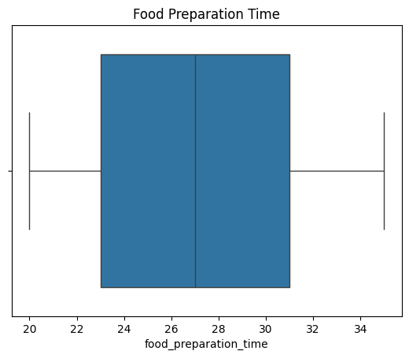

```python
sns.boxplot(data = df, x ='food_preparation_time')
plt.title("Food Preparation Time")
plt.show()
```

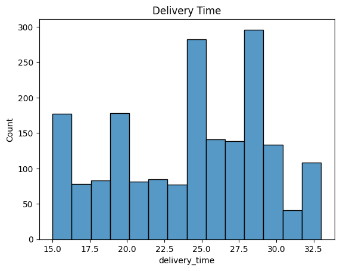

```python
sns.histplot(df['delivery_time'])
plt.title("Delivery Time")
```

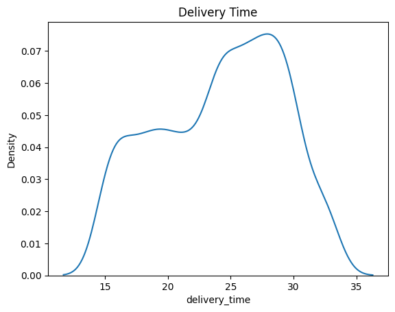

```python
sns.kdeplot(df['delivery_time'])
plt.title("Delivery Time")
```

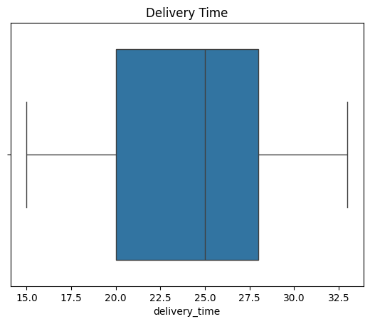

```python
sns.boxplot(data = df, x ='delivery_time')
plt.title("Delivery Time")
```

### Observations:

Food preparation time ranges from 20 to 35 minutes, with a fairly consistent distribution throughout and a slight peak in the 21-22 minute range.

Data on delivery times shows one peak of times around 18-21 minutes, and a following larger peak around 25-30 minutes, indicating two typical delivery speeds.

Data is somewhat tightly packed, with over 50% of times falling between 20 and 28 mintues.

```python
timing_by_day_query = """
SELECT
    day_of_the_week,
    COUNT(*) AS order_count,
    ROUND(AVG(food_preparation_time), 2) AS avg_prep_time,
    ROUND(AVG(delivery_time), 2) AS avg_delivery_time,
    ROUND(AVG(food_preparation_time + delivery_time), 2) AS avg_total_fulfillment_time
FROM orders
GROUP BY day_of_the_week
ORDER BY order_count DESC;
"""

pd.read_sql(timing_by_day_query, conn)
```

|  | day_of_the_week | order_count | avg_prep_time | avg_delivery_time | avg_total_fulfillment_time |
| --- | --- | --- | --- | --- | --- |
| 0 | Weekend | 1351 | 27.44 | 22.47 | 49.91 |
| 1 | Weekday | 547 | 27.21 | 28.34 | 55.55 |

```python
# Checking which cuisines are the most consistent with timing
timing_by_cuisine_query = """
SELECT
    cuisine_type,
    COUNT(*) AS order_count,
    ROUND(AVG(food_preparation_time), 2) AS avg_prep_time,
    ROUND(AVG(delivery_time), 2) AS avg_delivery_time,
    ROUND(AVG(food_preparation_time + delivery_time), 2) AS avg_total_fulfillment_time
FROM orders
GROUP BY cuisine_type
HAVING COUNT(*) >= 10
ORDER BY avg_total_fulfillment_time ASC;
"""

pd.read_sql(timing_by_cuisine_query, conn)
```

|  | cuisine_type | order_count | avg_prep_time | avg_delivery_time | avg_total_fulfillment_time |
| --- | --- | --- | --- | --- | --- |
| 0 | Korean | 13 | 25.46 | 20.92 | 46.38 |
| 1 | Spanish | 12 | 26.92 | 23.42 | 50.33 |
| 2 | Thai | 19 | 27.32 | 23.16 | 50.47 |
| 3 | Mediterranean | 46 | 27.00 | 23.59 | 50.59 |
| 4 | Middle Eastern | 49 | 26.67 | 24.08 | 50.76 |
| 5 | Mexican | 77 | 26.73 | 24.39 | 51.12 |
| 6 | Indian | 73 | 27.11 | 24.08 | 51.19 |
| 7 | Chinese | 215 | 27.51 | 23.86 | 51.37 |
| 8 | Southern | 17 | 27.59 | 23.82 | 51.41 |
| 9 | American | 584 | 27.44 | 24.19 | 51.63 |
| 10 | Japanese | 470 | 27.51 | 24.13 | 51.64 |
| 11 | Italian | 298 | 27.48 | 24.57 | 52.05 |
| 12 | French | 18 | 26.89 | 25.33 | 52.22 |

```python
# Checking which restaurants are the most consistent with timing
restaurant_timing_query = """
SELECT
    restaurant_name,
    COUNT(*) AS order_count,
    ROUND(AVG(food_preparation_time), 2) AS avg_prep_time,
    ROUND(AVG(delivery_time), 2) AS avg_delivery_time,
    ROUND(AVG(food_preparation_time + delivery_time), 2) AS avg_total_time
FROM orders
GROUP BY restaurant_name
HAVING COUNT(*) >= 5
ORDER BY avg_total_time ASC
LIMIT 15;
"""

pd.read_sql(restaurant_timing_query, conn)
```

|  | restaurant_name | order_count | avg_prep_time | avg_delivery_time | avg_total_time |
| --- | --- | --- | --- | --- | --- |
| 0 | Cho Dang Gol | 6 | 23.83 | 19.33 | 43.17 |
| 1 | Delicatessen | 5 | 27.20 | 19.40 | 46.60 |
| 2 | Westville Hudson | 15 | 25.67 | 21.73 | 47.40 |
| 3 | Benihana | 5 | 23.80 | 24.40 | 48.20 |
| 4 | Cafe Mogador | 18 | 25.28 | 22.94 | 48.22 |
| 5 | Five Guys Burgers and Fries | 29 | 25.62 | 23.41 | 49.03 |
| 6 | Waverly Diner | 7 | 25.00 | 24.14 | 49.14 |
| 7 | Blue Ribbon Sushi Bar & Grill | 44 | 26.30 | 23.41 | 49.70 |
| 8 | Sarabeth's Restaurant | 7 | 23.71 | 26.00 | 49.71 |
| 9 | Vanessa's Dumpling House | 9 | 25.56 | 24.22 | 49.78 |
| 10 | Chipotle Mexican Grill $1.99 Delivery | 23 | 26.00 | 23.87 | 49.87 |
| 11 | TAO | 49 | 26.78 | 23.16 | 49.94 |
| 12 | Hill Country Fried Chicken | 14 | 27.36 | 22.64 | 50.00 |
| 13 | The Smile | 18 | 26.11 | 23.89 | 50.00 |
| 14 | Sushi of Gari | 16 | 28.19 | 21.94 | 50.13 |

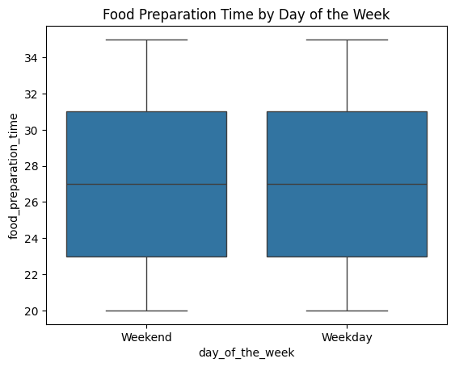

```python
# Checking food preparation time by day of the week
sns.boxplot(data=df, x='day_of_the_week', y='food_preparation_time')
plt.title("Food Preparation Time by Day of the Week")
```

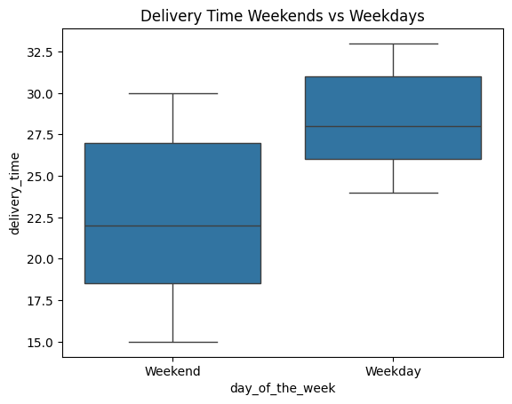

```python
# Checking food delivery time by day of the week
sns.boxplot(data=df, x='day_of_the_week', y='delivery_time')
plt.title("Delivery Time Weekends vs Weekdays")
```

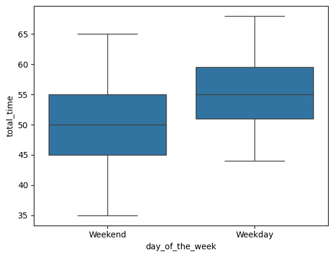

```python
# Creating a new column representative of total time for customer to receive order
df['total_time'] = df['food_preparation_time'] + df['delivery_time']
# Checking total waiting time by day of the week
sns.boxplot(data=df, x='day_of_the_week', y='total_time')
```

```python
# Checking the mean value of entries for delivery time
df['delivery_time'].mean()
```

```
np.float64(24.161749209694417)
```

### Observations:

The average delivery time for all orders is 24.16 minutes.

Comparing fulfillment metrics across weekday and weekend periods helps test whether weaker weekday demand may be associated with slower service times.

Weekend food preparation time strongly mirrors weekdays, suggesting businesses are staffing and preparing accordingly to keep up with higher weekend demand.

```python
timing_by_day_query = """
SELECT
    day_of_the_week,
    COUNT(*) AS order_count,
    ROUND(AVG(food_preparation_time), 2) AS avg_prep_time,
    ROUND(AVG(delivery_time), 2) AS avg_delivery_time,
    ROUND(AVG(food_preparation_time + delivery_time), 2) AS avg_total_fulfillment_time
FROM orders
GROUP BY day_of_the_week
ORDER BY order_count DESC;
"""

pd.read_sql(timing_by_day_query, conn)
```

|  | day_of_the_week | order_count | avg_prep_time | avg_delivery_time | avg_total_fulfillment_time |
| --- | --- | --- | --- | --- | --- |
| 0 | Weekend | 1351 | 27.44 | 22.47 | 49.91 |
| 1 | Weekday | 547 | 27.21 | 28.34 | 55.55 |

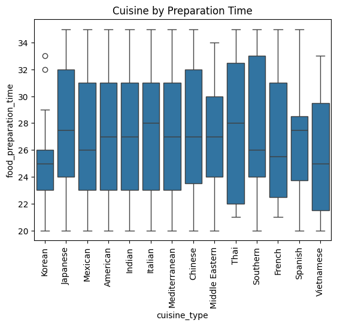

```python
sns.boxplot (data=df, x='cuisine_type', y='food_preparation_time')
plt.title("Cuisine by Preparation Time")
plt.xticks(rotation=90);
```

### Observations:

Korean has the most consistently fast preparation times, with a small range and low median.

Thai, Southern, and Spanish and Vietnamese hold the widest range of prep times.

Thai, Southern, Mediterranean and French have dishes that occasionaly take 35 minutes or more.

Most cuisines cluster around a similar median prep time of 26-29 minutes.

Weekends show an average and range of notably shorter delivery time than weekdays. With food preparation times remaining the same, one can reason that delivery drivers are moving faster to keep up with higher demand on weekends.

# Cost

```python
# Checking percentage of orders over $20
high_value_order_query = """
SELECT
    COUNT(*) AS total_orders,
    SUM(CASE WHEN cost_of_the_order > 20 THEN 1 ELSE 0 END) AS orders_above_20,
    ROUND(
        100.0 * SUM(CASE WHEN cost_of_the_order > 20 THEN 1 ELSE 0 END) / COUNT(*),
        2
    ) AS pct_orders_above_20
FROM orders;
"""

pd.read_sql(high_value_order_query, conn)
```

|  | total_orders | orders_above_20 | pct_orders_above_20 |
| --- | --- | --- | --- |
| 0 | 1898 | 555 | 29.24 |

```python
# Checking which cuisines generate the most revenue
cuisine_revenue_query = """
SELECT
    cuisine_type,
    COUNT(*) AS order_count,
    ROUND(SUM(cost_of_the_order), 2) AS total_revenue,
    ROUND(AVG(cost_of_the_order), 2) AS avg_order_value
FROM orders
GROUP BY cuisine_type
ORDER BY total_revenue DESC;
"""

pd.read_sql(cuisine_revenue_query, conn)
```

|  | cuisine_type | order_count | total_revenue | avg_order_value |
| --- | --- | --- | --- | --- |
| 0 | American | 584 | 9530.78 | 16.32 |
| 1 | Japanese | 470 | 7663.13 | 16.30 |
| 2 | Italian | 298 | 4892.77 | 16.42 |
| 3 | Chinese | 215 | 3505.62 | 16.31 |
| 4 | Mexican | 77 | 1303.85 | 16.93 |
| 5 | Indian | 73 | 1235.14 | 16.92 |
| 6 | Middle Eastern | 49 | 922.21 | 18.82 |
| 7 | Mediterranean | 46 | 711.84 | 15.47 |
| 8 | Thai | 19 | 364.95 | 19.21 |
| 9 | French | 18 | 356.29 | 19.79 |
| 10 | Southern | 17 | 328.11 | 19.30 |
| 11 | Spanish | 12 | 227.93 | 18.99 |
| 12 | Korean | 13 | 182.02 | 14.00 |
| 13 | Vietnamese | 7 | 90.18 | 12.88 |

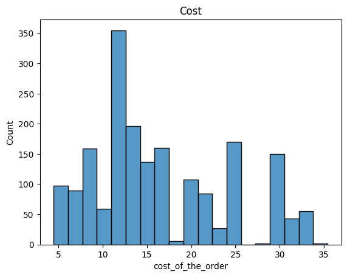

```python
sns.histplot(df['cost_of_the_order'])
plt.title("Cost")
```

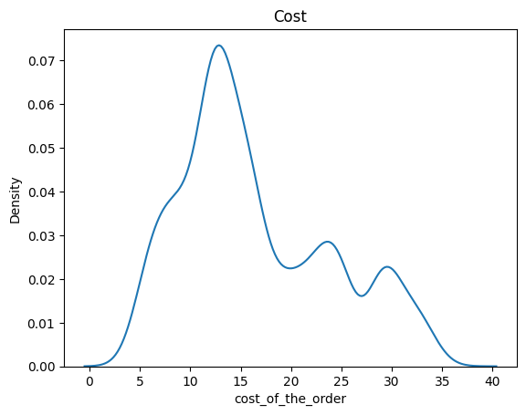

```python
sns.kdeplot(df['cost_of_the_order'])
plt.title("Cost")
```

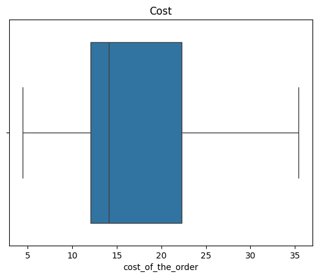

```python
sns.boxplot(data = df, x ='cost_of_the_order')
plt.title("Cost")
```

```python
# Checking the percentage of times the condition is true (>$20).
(df['cost_of_the_order'] > 20).mean() * 100
```

```
np.float64(29.24130663856691)
```

### Observations:

Data on order costs shows a positive skew with a long right tail extending towards the 30-40 dollar range.

Data is multi-modal with clusterings around 10-12 dollars, 15-18 dollars and 25-30 dollars. The dominant peak lays within the 13-14 dollar range.

Just over 29% of orders are above $20

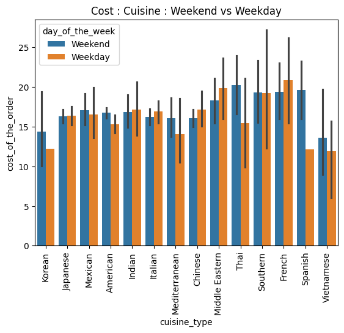

```python
# Visualizing cost breakdowns by cuisine and day of week
sns.barplot (data=df, x='cuisine_type', y='cost_of_the_order', hue = 'day_of_the_week')
plt.title("Cost : Cuisine : Weekend vs Weekday")
plt.xticks(rotation=90);
```

#### Thai, Southern and French show the highest average costs.

#### Vietnamese has the lowest average costs around 13 to 14 dollars.

#### Most cuisines fall in the 16 to 18 dollar range.

#### Several cuisines; most notably Thai, Spanish and Korean show a higher ratio of average weekend costs than other cuisines (more weekend than weekday), but it is not a strong difference.

# Cost x Time

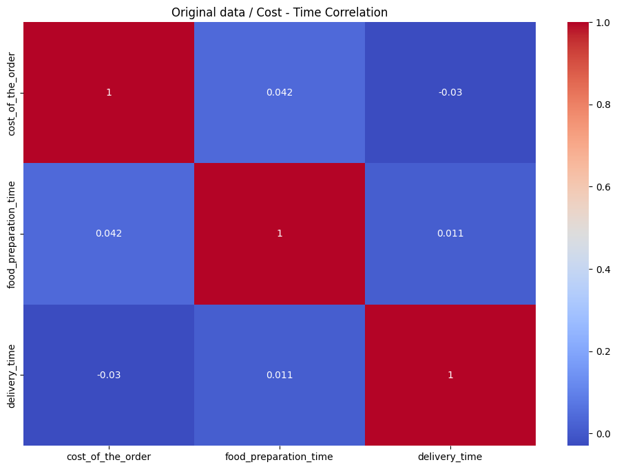

```python
# Creating a heatmap to visualize correlation strengths between cost, delivery time and food preparation time.
numeric_df = df[["cost_of_the_order", "food_preparation_time", "delivery_time"]]

corr = numeric_df.corr()

plt.figure(figsize=(12,8))
sns.heatmap(corr, annot=True, cmap='coolwarm')
plt.title("Original data / Cost - Time Correlation")
plt.show()
```

### Observations:

#### Higher costs technically produce generally higher ratings, but the findings aren't noteworthy.

```python
# Checking orders with ratings vs orders without
rating_quality_query = """
SELECT
    COUNT(*) AS total_orders,
    SUM(CASE WHEN rating = 'Not given' THEN 1 ELSE 0 END) AS ratings_not_given,
    SUM(CASE WHEN rating != 'Not given' THEN 1 ELSE 0 END) AS ratings_recorded
FROM orders;
"""

pd.read_sql(rating_quality_query, conn)
```

|  | total_orders | ratings_not_given | ratings_recorded |
| --- | --- | --- | --- |
| 0 | 1898 | 736 | 1162 |

### Key Takeaways:

#### Delivery time

There is a set of peaks at 5 minute intervals (15, 20, 25) ending with a highest peak at around 28 minutes

#### Cost

We can see a peak in the 13-14 dollar range, followed by a second upswing around 30 dollars (perhaps orders for two persons).

#### Ratings

Nearly 39% of orders are without ratings.

#### Cuisine

American, Japanese, Italian and Chinese are the four most popular cuisines, in that respective order. The top 5 most-ordered-from restaurants fall within those categories.

#### Additional notes

If Blue Ribbon Sushi and Blue Ribbon Fried Chicken belong to the same parent company; Blue Ribbons full sales are near equivalent to Shake Shack, indicating a cornering of the market. Our top 4 cuisines hold near 80% of all orders.

# Ratings

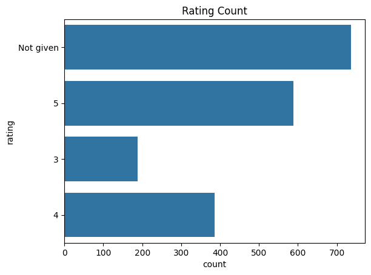

```python
# Checking the counts of ratings
sns.countplot(df['rating'])
plt.title("Rating Count")
plt.show()
```

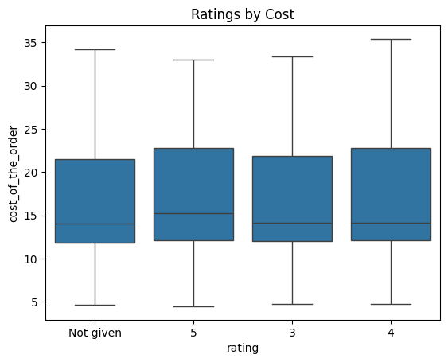

```python
# Visualizing order ratings by cost
sns.boxplot (data=df, x='rating', y='cost_of_the_order')
plt.title("Ratings by Cost")
```

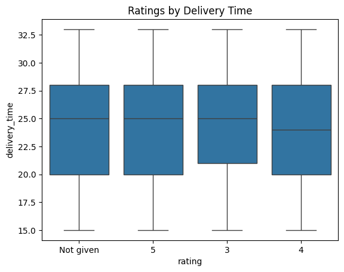

```python
# Visualizing order ratings by delivery time
sns.boxplot (data=df, x='rating', y='delivery_time')
plt.title("Ratings by Delivery Time")
```

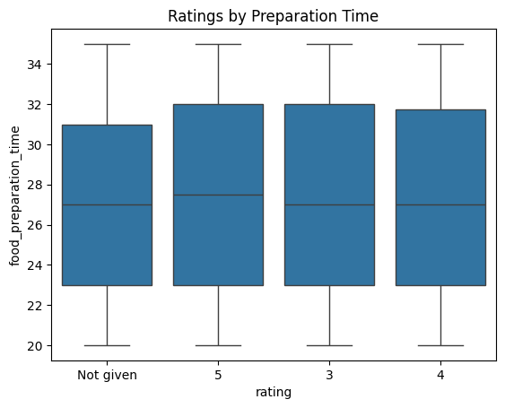

```python
# Visualizing order ratings by food prep time
sns.boxplot (data=df, x='rating', y='food_preparation_time')
plt.title("Ratings by Preparation Time")
```

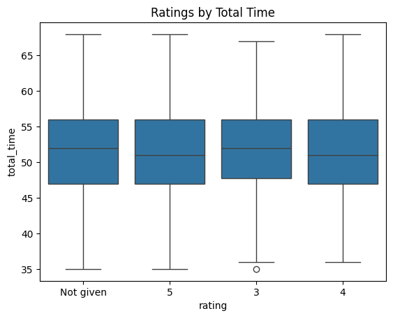

```python
# Visualizing ratings by total waiting time
sns.boxplot (data=df, x='rating', y='total_time')
plt.title("Ratings by Total Time")
```

### Observations:

#### Cost and all breakdowns of waiting time generally don't show strong correlations with rating. We see just as tightly packed a middle 50% of observations labeled 'Not Given' in ratings as we do 4 and 5 stars.

```python
# Rechecking ratings coverage
ratings_coverage_query = """
SELECT
    COUNT(*) AS total_orders,
    SUM(CASE WHEN rating = 'Not given' THEN 1 ELSE 0 END) AS ratings_missing,
    SUM(CASE WHEN rating != 'Not given' THEN 1 ELSE 0 END) AS ratings_recorded,
    ROUND(
        100.0 * SUM(CASE WHEN rating != 'Not given' THEN 1 ELSE 0 END) / COUNT(*),
        2
    ) AS pct_orders_with_rating
FROM orders;
"""

pd.read_sql(ratings_coverage_query, conn)
```

|  | total_orders | ratings_missing | ratings_recorded | pct_orders_with_rating |
| --- | --- | --- | --- | --- |
| 0 | 1898 | 736 | 1162 | 61.22 |

```python
rating_by_cuisine_query = """
SELECT
    cuisine_type,
    COUNT(*) AS rated_orders,
    ROUND(AVG(CAST(rating AS FLOAT)), 2) AS avg_rating
FROM orders
WHERE rating != 'Not given'
GROUP BY cuisine_type
HAVING COUNT(*) >= 10
ORDER BY avg_rating DESC, rated_orders DESC;
"""

pd.read_sql(rating_by_cuisine_query, conn)
```

|  | cuisine_type | rated_orders | avg_rating |
| --- | --- | --- | --- |
| 0 | Indian | 50 | 4.54 |
| 1 | Mexican | 48 | 4.42 |
| 2 | Japanese | 273 | 4.37 |
| 3 | Italian | 172 | 4.36 |
| 4 | Chinese | 133 | 4.34 |
| 5 | Southern | 13 | 4.31 |
| 6 | American | 368 | 4.30 |
| 7 | French | 10 | 4.30 |
| 8 | Middle Eastern | 34 | 4.24 |
| 9 | Mediterranean | 32 | 4.22 |

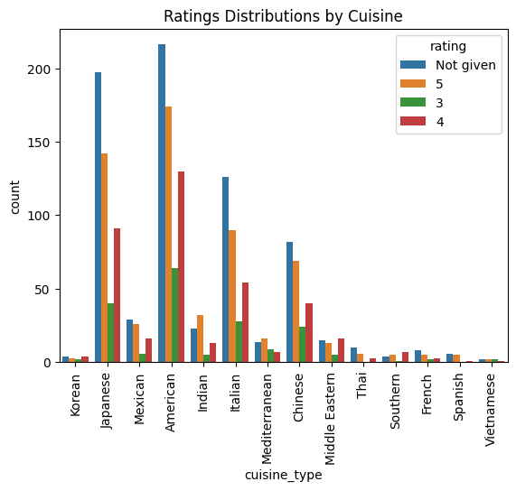

```python
# Checking rating distributions by cuisine
sns.countplot(data = df , x = 'cuisine_type', hue = 'rating')
plt.xticks(rotation=90)
plt.title("Ratings Distributions by Cuisine")
plt.show()
```

```python
# Average rating among recorded ratings
avg_rating_query = """
SELECT
    COUNT(*) AS rated_orders,
    ROUND(AVG(CAST(rating AS FLOAT)), 2) AS avg_rating,
    MIN(CAST(rating AS FLOAT)) AS min_rating,
    MAX(CAST(rating AS FLOAT)) AS max_rating
FROM orders
WHERE rating != 'Not given';
"""

pd.read_sql(avg_rating_query, conn)
```

|  | rated_orders | avg_rating | min_rating | max_rating |
| --- | --- | --- | --- | --- |
| 0 | 1162 | 4.34 | 3.0 | 5.0 |

```python
# Seeing if faster restaurants tend to rate better
rating_by_speed_band_query = """
SELECT
    CASE
        WHEN (food_preparation_time + delivery_time) < 40 THEN 'Under 40 min'
        WHEN (food_preparation_time + delivery_time) BETWEEN 40 AND 49 THEN '40-49 min'
        WHEN (food_preparation_time + delivery_time) BETWEEN 50 AND 59 THEN '50-59 min'
        ELSE '60+ min'
    END AS fulfillment_band,
    COUNT(*) AS rated_orders,
    ROUND(AVG(CAST(rating AS FLOAT)), 2) AS avg_rating
FROM orders
WHERE rating != 'Not given'
GROUP BY fulfillment_band
ORDER BY
    CASE fulfillment_band
        WHEN 'Under 40 min' THEN 1
        WHEN '40-49 min' THEN 2
        WHEN '50-59 min' THEN 3
        ELSE 4
    END;
"""

pd.read_sql(rating_by_speed_band_query, conn)
```

|  | fulfillment_band | rated_orders | avg_rating |
| --- | --- | --- | --- |
| 0 | Under 40 min | 47 | 4.38 |
| 1 | 40-49 min | 398 | 4.36 |
| 2 | 50-59 min | 571 | 4.32 |
| 3 | 60+ min | 146 | 4.37 |

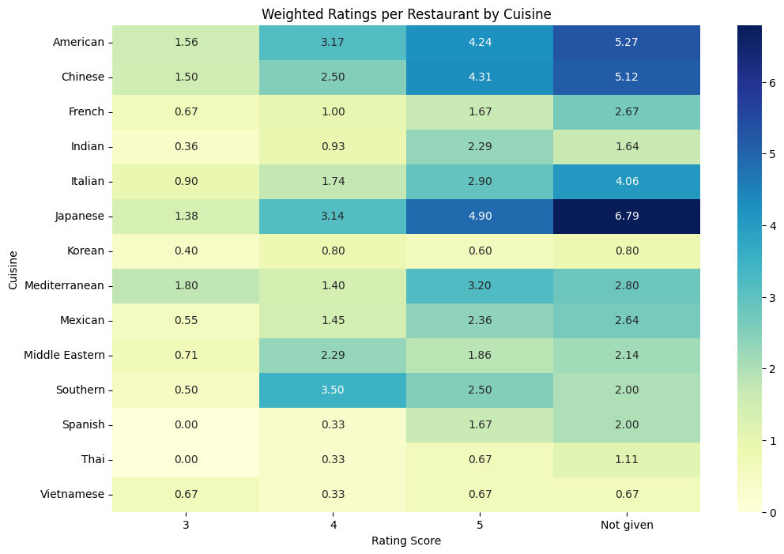

```python
# Counting number of unique restaurants per cuisine
restaurants_per_cuisine = df.groupby("cuisine_type")["restaurant_name"].nunique()

# Building rating counts per cuisine
rating_counts = df.pivot_table(
    index="cuisine_type",
    columns="rating",
    aggfunc="size",
    fill_value=0
)

# Applying weights by dividing each row by number of restaurants in that cuisine
weighted_rating_counts = rating_counts.div(restaurants_per_cuisine, axis=0)

weighted_rating_counts

# Generating a visual of correlation matrix
plt.figure(figsize=(12, 8))
sns.heatmap(
    weighted_rating_counts,
    annot=True,
    cmap="YlGnBu",
    fmt=".2f"
)
plt.title("Weighted Ratings per Restaurant by Cuisine")
plt.ylabel("Cuisine")
plt.xlabel("Rating Score")
plt.show()
```

### Observations:

##### The chart above shows the average amount of 3, 4, 5 and empty ratings received per restaurant by cuisine type. For example, your average American restaurant receives 8.97 ratings (summing 1.56, 3.17 and 4.24), whereas your average Korean restaurant receives 1.8 ratings (summing 0.4, 0.8 and 0.6).

##### We have already proven American, Japanese, and Chinese cuisines are 3 of the 4 leading in popular demand. The chart above shows they also each receive considerably higher amounts of reviews per restaurant than other cuisines.

##### A higher volume of restaurants produces a higher volume of orders and thus a higher opportunity for ratings.

```python
# Creating a table that groups amounts of 3-star, 4-star, 5-star and N/A by restaurant.
rating_summary = (
    df.groupby("restaurant_name")["rating"]
      .value_counts()
      .unstack(fill_value=0)
      .reset_index()
)
rating_summary
```

| rating | restaurant_name | 3 | 4 | 5 | Not given |
| --- | --- | --- | --- | --- | --- |
| 0 | 'wichcraft | 0 | 0 | 1 | 0 |
| 1 | 12 Chairs | 0 | 1 | 1 | 2 |
| 2 | 5 Napkin Burger | 1 | 0 | 1 | 3 |
| 3 | 67 Burger | 0 | 0 | 1 | 0 |
| 4 | Alidoro | 0 | 0 | 0 | 1 |
| ... | ... | ... | ... | ... | ... |
| 173 | Zero Otto Nove | 0 | 1 | 0 | 1 |
| 174 | brgr | 1 | 0 | 0 | 1 |
| 175 | da Umberto | 0 | 0 | 1 | 2 |
| 176 | ilili Restaurant | 2 | 7 | 4 | 5 |
| 177 | indikitch | 0 | 1 | 1 | 2 |

178 rows × 5 columns

```python
# Summing rating groups for total ratings given
rating_summary["total_ratings"] = rating_summary[["3", "4", "5"]].sum(axis=1)
rating_summary
```

| rating | restaurant_name | 3 | 4 | 5 | Not given | total_ratings |
| --- | --- | --- | --- | --- | --- | --- |
| 0 | 'wichcraft | 0 | 0 | 1 | 0 | 1 |
| 1 | 12 Chairs | 0 | 1 | 1 | 2 | 2 |
| 2 | 5 Napkin Burger | 1 | 0 | 1 | 3 | 2 |
| 3 | 67 Burger | 0 | 0 | 1 | 0 | 1 |
| 4 | Alidoro | 0 | 0 | 0 | 1 | 0 |
| ... | ... | ... | ... | ... | ... | ... |
| 173 | Zero Otto Nove | 0 | 1 | 0 | 1 | 1 |
| 174 | brgr | 1 | 0 | 0 | 1 | 1 |
| 175 | da Umberto | 0 | 0 | 1 | 2 | 1 |
| 176 | ilili Restaurant | 2 | 7 | 4 | 5 | 13 |
| 177 | indikitch | 0 | 1 | 1 | 2 | 2 |

178 rows × 6 columns

```python
# Creating series with total order counts by restaurant
order_counts = df["restaurant_name"].value_counts()

# Adding total order counts as a new column in rating_summary
rating_summary = rating_summary.set_index("restaurant_name")
rating_summary["order_count"] = order_counts
rating_summary = rating_summary.reset_index()
```

```python
# Finding average *amount* of ratings per order by dividing total ratings by order count.
rating_summary["avg_rating_per_order"] = (
    rating_summary["total_ratings"] / rating_summary["order_count"]
)
rating_summary
```

| rating | restaurant_name | 3 | 4 | 5 | Not given | total_ratings | order_count | avg_rating_per_order |
| --- | --- | --- | --- | --- | --- | --- | --- | --- |
| 0 | 'wichcraft | 0 | 0 | 1 | 0 | 1 | 1 | 1.000000 |
| 1 | 12 Chairs | 0 | 1 | 1 | 2 | 2 | 4 | 0.500000 |
| 2 | 5 Napkin Burger | 1 | 0 | 1 | 3 | 2 | 5 | 0.400000 |
| 3 | 67 Burger | 0 | 0 | 1 | 0 | 1 | 1 | 1.000000 |
| 4 | Alidoro | 0 | 0 | 0 | 1 | 0 | 1 | 0.000000 |
| ... | ... | ... | ... | ... | ... | ... | ... | ... |
| 173 | Zero Otto Nove | 0 | 1 | 0 | 1 | 1 | 2 | 0.500000 |
| 174 | brgr | 1 | 0 | 0 | 1 | 1 | 2 | 0.500000 |
| 175 | da Umberto | 0 | 0 | 1 | 2 | 1 | 3 | 0.333333 |
| 176 | ilili Restaurant | 2 | 7 | 4 | 5 | 13 | 18 | 0.722222 |
| 177 | indikitch | 0 | 1 | 1 | 2 | 2 | 4 | 0.500000 |

178 rows × 8 columns

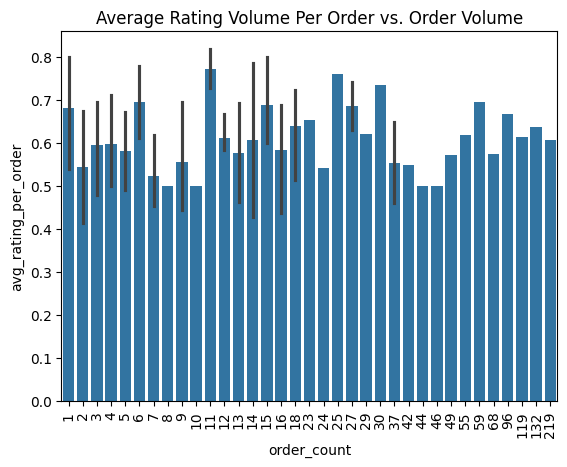

```python
# Visualizing the likelihood of an order receving a rating by restaurant volume
sns.barplot(data=rating_summary, x="order_count", y="avg_rating_per_order")
plt.xticks(rotation=90)
plt.title("Average Rating Volume Per Order vs. Order Volume")
```

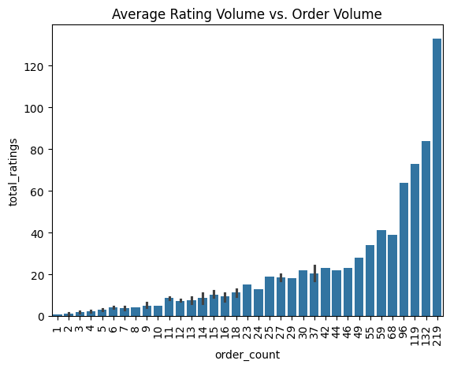

```python
# Visualizing the amount of ratings received in total by restaurant volume
sns.barplot(data=rating_summary, x="order_count", y="total_ratings")
plt.xticks(rotation=90)
plt.title("Average Rating Volume vs. Order Volume")
```

## A key observation:

Though the likelihood of a singular order receiving a rating does not necessarily increase with a restaurant's popularity, the overall **volume** of ratings left does show an exponential increase with order count. A higher volume of ratings spells out higher visibility and thus greater demand.

```python
# Calculating a dataframe that groups by restaurant name and includes order counts, average food prep time, average cost, and most common day of the week.
# 1. Group by restaurant
grouped = df.groupby("restaurant_name")

# 2. Build summary dataframe
summary = pd.DataFrame({
    "mean_food_prep_time": grouped["food_preparation_time"].mean(),
    "mean_cost": grouped["cost_of_the_order"].mean(),
    "order_count": grouped.size(),   # counts number of rows per restaurant
})

# 3. Add mode of day_of_the_week
summary["mode_day_of_week"] = grouped["day_of_the_week"].agg(
    lambda x: x.mode().iloc[0] if not x.mode().empty else None
)

summary.head()
```

| restaurant_name | mean_food_prep_time | mean_cost | order_count | mode_day_of_week |
| --- | --- | --- | --- | --- |
| 'wichcraft | 28.0 | 8.1000 | 1 | Weekday |
| 12 Chairs | 27.0 | 22.1425 | 4 | Weekday |
| 5 Napkin Burger | 30.2 | 15.9680 | 5 | Weekend |
| 67 Burger | 20.0 | 29.0500 | 1 | Weekday |
| Alidoro | 34.0 | 12.6100 | 1 | Weekend |